# Week 5

```python
from __future__ import print_function, division

%matplotlib inline

import numpy as np

import nsfg
import first
import thinkstats2
import thinkplot
```

## Probability mass functions

Again, I'll load the NSFG pregnancy file and select live births:

```python
t = [1, 2, 2, 3, 5,3,2,5,2,4,1,2,3,2,5,1,2,2,2,2]
```

```python
t
```

```
[1, 2, 2, 3, 5, 3, 2, 5, 2, 4, 1, 2, 3, 2, 5, 1, 2, 2, 2, 2]
```

```python
preg = nsfg.ReadFemPreg()
live = preg[preg.outcome == 1]
```

```python
live
```

|  | caseid | pregordr | howpreg_n | howpreg_p | moscurrp | nowprgdk | pregend1 | pregend2 | nbrnaliv | multbrth | ... | laborfor_i | religion_i | metro_i | basewgt | adj_mod_basewgt | finalwgt | secu_p | sest | cmintvw | totalwgt_lb |
| --- | --- | --- | --- | --- | --- | --- | --- | --- | --- | --- | --- | --- | --- | --- | --- | --- | --- | --- | --- | --- | --- |
| 0 | 1 | 1 | NaN | NaN | NaN | NaN | 6.0 | NaN | 1.0 | NaN | ... | 0 | 0 | 0 | 3410.389399 | 3869.349602 | 6448.271112 | 2 | 9 | NaN | 8.8125 |
| 1 | 1 | 2 | NaN | NaN | NaN | NaN | 6.0 | NaN | 1.0 | NaN | ... | 0 | 0 | 0 | 3410.389399 | 3869.349602 | 6448.271112 | 2 | 9 | NaN | 7.8750 |
| 2 | 2 | 1 | NaN | NaN | NaN | NaN | 5.0 | NaN | 3.0 | 5.0 | ... | 0 | 0 | 0 | 7226.301740 | 8567.549110 | 12999.542264 | 2 | 12 | NaN | 9.1250 |
| 3 | 2 | 2 | NaN | NaN | NaN | NaN | 6.0 | NaN | 1.0 | NaN | ... | 0 | 0 | 0 | 7226.301740 | 8567.549110 | 12999.542264 | 2 | 12 | NaN | 7.0000 |
| 4 | 2 | 3 | NaN | NaN | NaN | NaN | 6.0 | NaN | 1.0 | NaN | ... | 0 | 0 | 0 | 7226.301740 | 8567.549110 | 12999.542264 | 2 | 12 | NaN | 6.1875 |
| 5 | 6 | 1 | NaN | NaN | NaN | NaN | 6.0 | NaN | 1.0 | NaN | ... | 0 | 0 | 0 | 4870.926435 | 5325.196999 | 8874.440799 | 1 | 23 | NaN | 8.5625 |
| 6 | 6 | 2 | NaN | NaN | NaN | NaN | 6.0 | NaN | 1.0 | NaN | ... | 0 | 0 | 0 | 4870.926435 | 5325.196999 | 8874.440799 | 1 | 23 | NaN | 9.5625 |
| 7 | 6 | 3 | NaN | NaN | NaN | NaN | 6.0 | NaN | 1.0 | NaN | ... | 0 | 0 | 0 | 4870.926435 | 5325.196999 | 8874.440799 | 1 | 23 | NaN | 8.3750 |
| 8 | 7 | 1 | NaN | NaN | NaN | NaN | 5.0 | NaN | 1.0 | NaN | ... | 0 | 0 | 0 | 3409.579565 | 3787.539000 | 6911.879921 | 2 | 14 | NaN | 7.5625 |
| 9 | 7 | 2 | NaN | NaN | NaN | NaN | 5.0 | NaN | 1.0 | NaN | ... | 0 | 0 | 0 | 3409.579565 | 3787.539000 | 6911.879921 | 2 | 14 | NaN | 6.6250 |
| 10 | 12 | 1 | NaN | NaN | NaN | NaN | 5.0 | NaN | 1.0 | NaN | ... | 0 | 0 | 0 | 3612.781968 | 4146.013572 | 6909.331618 | 1 | 31 | NaN | 7.8125 |
| 11 | 14 | 1 | NaN | NaN | NaN | NaN | 6.0 | NaN | 1.0 | NaN | ... | 0 | 0 | 0 | 2418.069494 | 2810.302771 | 3039.904507 | 2 | 56 | NaN | 7.0000 |
| 12 | 14 | 2 | NaN | NaN | NaN | NaN | 6.0 | NaN | 1.0 | NaN | ... | 0 | 0 | 0 | 2418.069494 | 2810.302771 | 3039.904507 | 2 | 56 | NaN | 4.0000 |
| 15 | 15 | 2 | NaN | NaN | NaN | NaN | 6.0 | NaN | 1.0 | NaN | ... | 0 | 0 | 0 | 1667.816099 | 3200.862017 | 5553.495599 | 1 | 33 | NaN | 7.6875 |
| 16 | 15 | 3 | NaN | NaN | NaN | NaN | 6.0 | NaN | 1.0 | NaN | ... | 0 | 0 | 0 | 1667.816099 | 3200.862017 | 5553.495599 | 1 | 33 | NaN | 7.5000 |
| 17 | 18 | 1 | NaN | NaN | NaN | NaN | 5.0 | NaN | 1.0 | NaN | ... | 0 | 0 | 0 | 2957.257457 | 3404.403067 | 4153.371741 | 2 | 14 | NaN | 6.3125 |
| 19 | 21 | 1 | NaN | NaN | NaN | NaN | 6.0 | NaN | 1.0 | NaN | ... | 0 | 0 | 0 | 3408.342437 | 3965.763949 | 7237.122630 | 1 | 48 | NaN | 8.7500 |
| 20 | 21 | 2 | NaN | NaN | NaN | NaN | 6.0 | NaN | 1.0 | NaN | ... | 0 | 0 | 0 | 3408.342437 | 3965.763949 | 7237.122630 | 1 | 48 | NaN | 8.1875 |
| 21 | 23 | 1 | NaN | NaN | NaN | NaN | 6.0 | NaN | 1.0 | NaN | ... | 0 | 0 | 0 | 6210.373020 | 8120.841310 | 13533.382043 | 2 | 64 | NaN | 5.5625 |
| 23 | 24 | 1 | NaN | NaN | NaN | NaN | 6.0 | NaN | 1.0 | NaN | ... | 0 | 0 | 0 | 3409.573258 | 4068.628645 | 7424.840414 | 1 | 27 | NaN | 6.7500 |
| 24 | 24 | 2 | NaN | NaN | NaN | NaN | 6.0 | NaN | 1.0 | NaN | ... | 0 | 0 | 0 | 3409.573258 | 4068.628645 | 7424.840414 | 1 | 27 | NaN | 7.3750 |
| 25 | 24 | 3 | NaN | NaN | NaN | NaN | 6.0 | NaN | 1.0 | NaN | ... | 0 | 0 | 0 | 3409.573258 | 4068.628645 | 7424.840414 | 1 | 27 | NaN | 6.8125 |
| 26 | 28 | 1 | NaN | NaN | NaN | NaN | 6.0 | NaN | 1.0 | NaN | ... | 0 | 0 | 0 | 3407.794208 | 3808.343516 | 6949.846082 | 2 | 57 | NaN | 8.1250 |
| 27 | 31 | 1 | NaN | NaN | NaN | NaN | 6.0 | NaN | 1.0 | NaN | ... | 0 | 0 | 0 | 3405.679025 | 4272.084519 | 5211.943113 | 1 | 2 | NaN | 7.1250 |
| 28 | 31 | 2 | NaN | NaN | NaN | NaN | 6.0 | NaN | 1.0 | NaN | ... | 0 | 0 | 0 | 3405.679025 | 4272.084519 | 5211.943113 | 1 | 2 | NaN | 6.0625 |
| 29 | 31 | 3 | NaN | NaN | NaN | NaN | 6.0 | NaN | 1.0 | NaN | ... | 0 | 0 | 0 | 3405.679025 | 4272.084519 | 5211.943113 | 1 | 2 | NaN | 7.4375 |
| 31 | 36 | 2 | NaN | NaN | NaN | NaN | 6.0 | NaN | 1.0 | NaN | ... | 0 | 0 | 0 | 1668.415087 | 1969.717778 | 3594.537973 | 1 | 69 | NaN | 8.0000 |
| 32 | 38 | 1 | NaN | NaN | NaN | NaN | 5.0 | NaN | 1.0 | NaN | ... | 0 | 0 | 0 | 4780.758522 | 5555.002527 | 10137.324111 | 2 | 36 | NaN | 7.5000 |
| 33 | 38 | 2 | NaN | NaN | NaN | NaN | 6.0 | NaN | 1.0 | NaN | ... | 0 | 0 | 0 | 4780.758522 | 5555.002527 | 10137.324111 | 2 | 36 | NaN | 7.2500 |
| 34 | 38 | 3 | NaN | NaN | NaN | NaN | 6.0 | NaN | 1.0 | NaN | ... | 0 | 0 | 0 | 4780.758522 | 5555.002527 | 10137.324111 | 2 | 36 | NaN | 7.1250 |
| ... | ... | ... | ... | ... | ... | ... | ... | ... | ... | ... | ... | ... | ... | ... | ... | ... | ... | ... | ... | ... | ... |
| 13548 | 12539 | 2 | NaN | NaN | NaN | NaN | 5.0 | NaN | 1.0 | NaN | ... | 0 | 0 | 0 | 2580.696230 | 3021.661943 | 5514.230879 | 1 | 14 | NaN | 10.0625 |
| 13551 | 12541 | 1 | NaN | NaN | NaN | NaN | 6.0 | NaN | 1.0 | NaN | ... | 0 | 0 | 0 | 3248.105346 | 4194.073923 | 5322.699216 | 2 | 45 | NaN | 5.3750 |
| 13552 | 12541 | 2 | NaN | NaN | NaN | NaN | 6.0 | NaN | 1.0 | NaN | ... | 0 | 0 | 0 | 3248.105346 | 4194.073923 | 5322.699216 | 2 | 45 | NaN | NaN |
| 13553 | 12541 | 3 | NaN | NaN | NaN | NaN | 6.0 | NaN | 1.0 | NaN | ... | 0 | 0 | 0 | 3248.105346 | 4194.073923 | 5322.699216 | 2 | 45 | NaN | 7.5000 |
| 13554 | 12541 | 4 | NaN | NaN | NaN | NaN | 6.0 | NaN | 1.0 | NaN | ... | 0 | 0 | 0 | 3248.105346 | 4194.073923 | 5322.699216 | 2 | 45 | NaN | NaN |
| 13555 | 12544 | 1 | NaN | NaN | NaN | NaN | 5.0 | NaN | 1.0 | NaN | ... | 0 | 0 | 0 | 5197.958762 | 5779.040455 | 7334.180241 | 1 | 17 | NaN | 6.1250 |
| 13556 | 12544 | 2 | NaN | NaN | NaN | NaN | 5.0 | NaN | 1.0 | NaN | ... | 0 | 0 | 0 | 5197.958762 | 5779.040455 | 7334.180241 | 1 | 17 | NaN | 7.1250 |
| 13557 | 12544 | 3 | NaN | NaN | NaN | NaN | 5.0 | NaN | 1.0 | NaN | ... | 0 | 0 | 0 | 5197.958762 | 5779.040455 | 7334.180241 | 1 | 17 | NaN | 6.5000 |
| 13559 | 12545 | 2 | NaN | NaN | NaN | NaN | 6.0 | NaN | 1.0 | NaN | ... | 0 | 0 | 0 | 6704.586080 | 8349.765651 | 13914.884458 | 2 | 53 | NaN | 7.8750 |
| 13560 | 12546 | 1 | NaN | NaN | NaN | NaN | 6.0 | NaN | 1.0 | NaN | ... | 0 | 0 | 0 | 4602.798759 | 7717.382897 | 9415.207134 | 1 | 29 | NaN | 7.8750 |
| 13561 | 12546 | 2 | NaN | NaN | NaN | NaN | 6.0 | NaN | 1.0 | NaN | ... | 0 | 0 | 0 | 4602.798759 | 7717.382897 | 9415.207134 | 1 | 29 | NaN | 6.8750 |
| 13562 | 12547 | 1 | NaN | NaN | NaN | NaN | 6.0 | NaN | 1.0 | NaN | ... | 0 | 0 | 0 | 3453.545517 | 6628.022524 | 11499.619080 | 1 | 52 | NaN | 8.1250 |
| 13563 | 12547 | 2 | NaN | NaN | NaN | NaN | 6.0 | NaN | 1.0 | NaN | ... | 0 | 0 | 0 | 3453.545517 | 6628.022524 | 11499.619080 | 1 | 52 | NaN | 7.6875 |
| 13564 | 12547 | 3 | NaN | NaN | NaN | NaN | 6.0 | NaN | 1.0 | NaN | ... | 0 | 0 | 0 | 3453.545517 | 6628.022524 | 11499.619080 | 1 | 52 | NaN | 7.6250 |
| 13565 | 12550 | 1 | NaN | NaN | NaN | NaN | 6.0 | NaN | 1.0 | NaN | ... | 0 | 0 | 0 | 3080.452699 | 3745.326058 | 5268.550165 | 1 | 79 | NaN | 8.1250 |
| 13566 | 12551 | 1 | NaN | NaN | NaN | NaN | 5.0 | NaN | 1.0 | NaN | ... | 0 | 0 | 0 | 2418.538866 | 3653.453268 | 3951.940400 | 2 | 75 | NaN | 7.5000 |
| 13569 | 12556 | 1 | NaN | NaN | NaN | NaN | 6.0 | NaN | 1.0 | NaN | ... | 0 | 0 | 0 | 2474.619764 | 3250.573384 | 3965.699528 | 1 | 44 | NaN | 5.8125 |
| 13570 | 12556 | 2 | NaN | NaN | NaN | NaN | 6.0 | NaN | 1.0 | NaN | ... | 0 | 0 | 0 | 2474.619764 | 3250.573384 | 3965.699528 | 1 | 44 | NaN | 6.6875 |
| 13571 | 12556 | 3 | NaN | NaN | NaN | NaN | 6.0 | NaN | 1.0 | NaN | ... | 0 | 0 | 0 | 2474.619764 | 3250.573384 | 3965.699528 | 1 | 44 | NaN | 6.0000 |
| 13572 | 12556 | 4 | NaN | NaN | NaN | NaN | 6.0 | NaN | 1.0 | NaN | ... | 0 | 0 | 0 | 2474.619764 | 3250.573384 | 3965.699528 | 1 | 44 | NaN | 5.8125 |
| 13573 | 12561 | 1 | NaN | NaN | NaN | NaN | 6.0 | NaN | 1.0 | NaN | ... | 0 | 0 | 0 | 2418.089703 | 2698.650781 | 4497.301527 | 1 | 10 | NaN | 6.5625 |
| 13574 | 12561 | 2 | NaN | NaN | NaN | NaN | 6.0 | NaN | 1.0 | NaN | ... | 0 | 0 | 0 | 2418.089703 | 2698.650781 | 4497.301527 | 1 | 10 | NaN | 6.1250 |
| 13576 | 12565 | 1 | NaN | NaN | NaN | NaN | 6.0 | NaN | 1.0 | NaN | ... | 0 | 0 | 0 | 3195.641221 | 3834.241709 | 6652.409365 | 1 | 78 | NaN | 6.4375 |
| 13578 | 12566 | 1 | NaN | NaN | NaN | NaN | 6.0 | NaN | 1.0 | NaN | ... | 0 | 0 | 0 | 2080.317155 | 2422.820274 | 2627.548587 | 2 | 2 | NaN | 6.0000 |
| 13579 | 12566 | 2 | NaN | NaN | NaN | NaN | 6.0 | NaN | 1.0 | NaN | ... | 0 | 0 | 0 | 2080.317155 | 2422.820274 | 2627.548587 | 2 | 2 | NaN | 7.0000 |
| 13581 | 12568 | 2 | NaN | NaN | NaN | NaN | 5.0 | NaN | 1.0 | NaN | ... | 0 | 0 | 0 | 2734.687353 | 4258.980140 | 7772.212858 | 2 | 28 | NaN | 6.3750 |
| 13584 | 12569 | 2 | NaN | NaN | NaN | NaN | 6.0 | NaN | 1.0 | NaN | ... | 0 | 0 | 0 | 2580.967613 | 2925.167116 | 5075.164946 | 2 | 61 | NaN | 6.3750 |
| 13588 | 12571 | 1 | NaN | NaN | NaN | NaN | 6.0 | NaN | 1.0 | NaN | ... | 0 | 0 | 0 | 4670.540953 | 5795.692880 | 6269.200989 | 1 | 78 | NaN | 6.1875 |
| 13591 | 12571 | 4 | NaN | NaN | NaN | NaN | 6.0 | NaN | 1.0 | NaN | ... | 0 | 0 | 0 | 4670.540953 | 5795.692880 | 6269.200989 | 1 | 78 | NaN | 7.5000 |
| 13592 | 12571 | 5 | NaN | NaN | NaN | NaN | 6.0 | NaN | 1.0 | NaN | ... | 0 | 0 | 0 | 4670.540953 | 5795.692880 | 6269.200989 | 1 | 78 | NaN | 7.5000 |

9148 rows × 244 columns

Here's the histogram of birth weights:

```python
hist = thinkstats2.Hist(live.birthwgt_lb, label='birthwgt_lb')
hist
```

```
Hist({0.0: 8, 1.0: 40, 2.0: 53, 3.0: 98, 4.0: 229, 5.0: 697, 6.0: 2223, 7.0: 3049, 8.0: 1889, 9.0: 623, 10.0: 132, 11.0: 26, 12.0: 10, 13.0: 3, 14.0: 3, 15.0: 1})
```

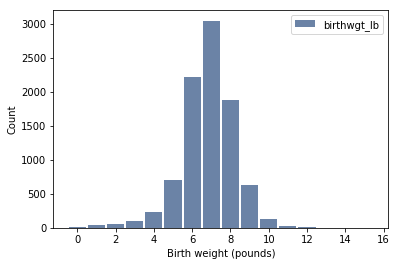

```python
thinkplot.Hist(hist)
thinkplot.Config(xlabel='Birth weight (pounds)', ylabel='Count')
```

To normalize the disrtibution, we could divide through by the total count:

```python
n = hist.Total()
pmf = hist.Copy()
for x, freq in hist.Items():
    print(x,freq,n)
    hist[x] = freq / n
    print(hist[x])

hist
```

```
0.0 8 9084
0.000880669308675
1.0 40 9084
0.00440334654337
2.0 53 9084
0.00583443416997
3.0 98 9084
0.0107881990313
4.0 229 9084
0.0252091589608
5.0 697 9084
0.0767283135183
6.0 2223 9084
0.244715984148
7.0 3049 9084
0.335645090269
8.0 1889 9084
0.207948040511
9.0 623 9084
0.068582122413
10.0 132 9084
0.0145310435931
11.0 26 9084
0.00286217525319
12.0 10 9084
0.00110083663584
13.0 3 9084
0.000330250990753
14.0 3 9084
0.000330250990753
15.0 1 9084
0.000110083663584
```

```
Hist({0.0: 0.00088066930867459266, 1.0: 0.0044033465433729636, 2.0: 0.0058344341699691762, 3.0: 0.010788199031263761, 4.0: 0.025209158960810215, 5.0: 0.076728313518273888, 6.0: 0.24471598414795245, 7.0: 0.33564509026860412, 8.0: 0.20794804051078819, 9.0: 0.068582122413033908, 10.0: 0.014531043593130…
```

The result is a Probability Mass Function (PMF).

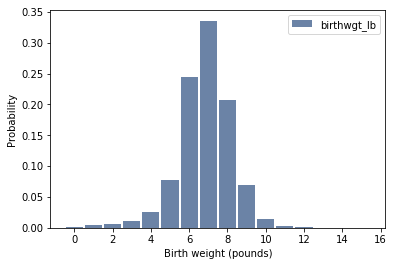

```python
thinkplot.Hist(hist)
thinkplot.Config(xlabel='Birth weight (pounds)', ylabel='Probability')
```

More directly, we can create a Pmf object.

```python
pmf = thinkstats2.Pmf([1, 2, 2, 3, 5,3,2,5,2,4,1,2,3,2,5,1,2,2,2,2])
pmf
```

```
Pmf({1: 0.15000000000000002, 2: 0.5, 3: 0.15000000000000002, 4: 0.05, 5: 0.15000000000000002})
```

`Pmf` provides `Prob`, which looks up a value and returns its probability:

```python
pmf.Prob(4)
```

```
0.05
```

The bracket operator does the same thing.

```python
pmf[2]
```

```
0.5
```

The `Incr` method adds to the probability associated with a given values.

```python
pmf.Incr(2, 0.2)
pmf[2]
```

```
0.7
```

```python
pmf
```

```
Pmf({1: 0.15000000000000002, 2: 0.7, 3: 0.15000000000000002, 4: 0.05, 5: 0.15000000000000002})
```

The `Mult` method multiplies the probability associated with a value.

```python
pmf.Mult(2, 0.5)
pmf[2]
```

```
0.35
```

`Total` returns the total probability (which is no longer 1, because we changed one of the probabilities).

```python
pmf.Total()
```

```
0.8500000000000001
```

```python
pmf
```

```
Pmf({1: 0.15000000000000002, 2: 0.35, 3: 0.15000000000000002, 4: 0.05, 5: 0.15000000000000002})
```

`Normalize` divides through by the total probability, making it 1 again.

```python
pmf.Normalize()
pmf.Total()
```

```
1.0
```

```python
pmf
```

```
Pmf({1: 0.17647058823529413, 2: 0.41176470588235287, 3: 0.17647058823529413, 4: 0.0588235294117647, 5: 0.17647058823529413})
```

- To plot a Pmf as a bar graph, you can use thinkplot.Hist . Bar graphs are most useful if the number of values in the Pmf is small.

- To plot a Pmf as a step function, you can use thinkplot.Pmf . This option is most useful if there are a large number of values and the Pmf is smooth. This function also works with Hist objects.

Here's the PMF of pregnancy length for live births.

```python
pmf1 = thinkstats2.Pmf(live.prglngth, label='prglngth')
pmf1
```

```
Pmf({0: 0.00010931351114997814, 4: 0.00010931351114997814, 9: 0.00010931351114997814, 13: 0.00010931351114997814, 17: 0.00021862702229995628, 18: 0.00010931351114997814, 19: 0.00010931351114997814, 20: 0.00010931351114997814, 21: 0.00021862702229995628, 22: 0.00076519457804984699, 23: 0.000109313511…
```

Here's what it looks like plotted with `Hist`, which makes a bar graph.

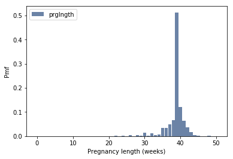

```python
thinkplot.Hist(pmf1)
thinkplot.Config(xlabel='Pregnancy length (weeks)', ylabel='Pmf')
```

Here's what it looks like plotted with `Pmf`, which makes a step function.

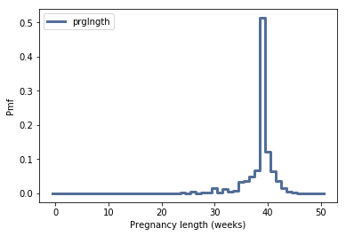

```python
thinkplot.Pmf(pmf1)
thinkplot.Config(xlabel='Pregnancy length (weeks)', ylabel='Pmf')
```

We can use `MakeFrames` to return DataFrames for all live births, first babies, and others.

```python
live, firsts, others = first.MakeFrames()
live
```

|  | caseid | pregordr | howpreg_n | howpreg_p | moscurrp | nowprgdk | pregend1 | pregend2 | nbrnaliv | multbrth | ... | laborfor_i | religion_i | metro_i | basewgt | adj_mod_basewgt | finalwgt | secu_p | sest | cmintvw | totalwgt_lb |
| --- | --- | --- | --- | --- | --- | --- | --- | --- | --- | --- | --- | --- | --- | --- | --- | --- | --- | --- | --- | --- | --- |
| 0 | 1 | 1 | NaN | NaN | NaN | NaN | 6.0 | NaN | 1.0 | NaN | ... | 0 | 0 | 0 | 3410.389399 | 3869.349602 | 6448.271112 | 2 | 9 | NaN | 8.8125 |
| 1 | 1 | 2 | NaN | NaN | NaN | NaN | 6.0 | NaN | 1.0 | NaN | ... | 0 | 0 | 0 | 3410.389399 | 3869.349602 | 6448.271112 | 2 | 9 | NaN | 7.8750 |
| 2 | 2 | 1 | NaN | NaN | NaN | NaN | 5.0 | NaN | 3.0 | 5.0 | ... | 0 | 0 | 0 | 7226.301740 | 8567.549110 | 12999.542264 | 2 | 12 | NaN | 9.1250 |
| 3 | 2 | 2 | NaN | NaN | NaN | NaN | 6.0 | NaN | 1.0 | NaN | ... | 0 | 0 | 0 | 7226.301740 | 8567.549110 | 12999.542264 | 2 | 12 | NaN | 7.0000 |
| 4 | 2 | 3 | NaN | NaN | NaN | NaN | 6.0 | NaN | 1.0 | NaN | ... | 0 | 0 | 0 | 7226.301740 | 8567.549110 | 12999.542264 | 2 | 12 | NaN | 6.1875 |
| 5 | 6 | 1 | NaN | NaN | NaN | NaN | 6.0 | NaN | 1.0 | NaN | ... | 0 | 0 | 0 | 4870.926435 | 5325.196999 | 8874.440799 | 1 | 23 | NaN | 8.5625 |
| 6 | 6 | 2 | NaN | NaN | NaN | NaN | 6.0 | NaN | 1.0 | NaN | ... | 0 | 0 | 0 | 4870.926435 | 5325.196999 | 8874.440799 | 1 | 23 | NaN | 9.5625 |
| 7 | 6 | 3 | NaN | NaN | NaN | NaN | 6.0 | NaN | 1.0 | NaN | ... | 0 | 0 | 0 | 4870.926435 | 5325.196999 | 8874.440799 | 1 | 23 | NaN | 8.3750 |
| 8 | 7 | 1 | NaN | NaN | NaN | NaN | 5.0 | NaN | 1.0 | NaN | ... | 0 | 0 | 0 | 3409.579565 | 3787.539000 | 6911.879921 | 2 | 14 | NaN | 7.5625 |
| 9 | 7 | 2 | NaN | NaN | NaN | NaN | 5.0 | NaN | 1.0 | NaN | ... | 0 | 0 | 0 | 3409.579565 | 3787.539000 | 6911.879921 | 2 | 14 | NaN | 6.6250 |
| 10 | 12 | 1 | NaN | NaN | NaN | NaN | 5.0 | NaN | 1.0 | NaN | ... | 0 | 0 | 0 | 3612.781968 | 4146.013572 | 6909.331618 | 1 | 31 | NaN | 7.8125 |
| 11 | 14 | 1 | NaN | NaN | NaN | NaN | 6.0 | NaN | 1.0 | NaN | ... | 0 | 0 | 0 | 2418.069494 | 2810.302771 | 3039.904507 | 2 | 56 | NaN | 7.0000 |
| 12 | 14 | 2 | NaN | NaN | NaN | NaN | 6.0 | NaN | 1.0 | NaN | ... | 0 | 0 | 0 | 2418.069494 | 2810.302771 | 3039.904507 | 2 | 56 | NaN | 4.0000 |
| 15 | 15 | 2 | NaN | NaN | NaN | NaN | 6.0 | NaN | 1.0 | NaN | ... | 0 | 0 | 0 | 1667.816099 | 3200.862017 | 5553.495599 | 1 | 33 | NaN | 7.6875 |
| 16 | 15 | 3 | NaN | NaN | NaN | NaN | 6.0 | NaN | 1.0 | NaN | ... | 0 | 0 | 0 | 1667.816099 | 3200.862017 | 5553.495599 | 1 | 33 | NaN | 7.5000 |
| 17 | 18 | 1 | NaN | NaN | NaN | NaN | 5.0 | NaN | 1.0 | NaN | ... | 0 | 0 | 0 | 2957.257457 | 3404.403067 | 4153.371741 | 2 | 14 | NaN | 6.3125 |
| 19 | 21 | 1 | NaN | NaN | NaN | NaN | 6.0 | NaN | 1.0 | NaN | ... | 0 | 0 | 0 | 3408.342437 | 3965.763949 | 7237.122630 | 1 | 48 | NaN | 8.7500 |
| 20 | 21 | 2 | NaN | NaN | NaN | NaN | 6.0 | NaN | 1.0 | NaN | ... | 0 | 0 | 0 | 3408.342437 | 3965.763949 | 7237.122630 | 1 | 48 | NaN | 8.1875 |
| 21 | 23 | 1 | NaN | NaN | NaN | NaN | 6.0 | NaN | 1.0 | NaN | ... | 0 | 0 | 0 | 6210.373020 | 8120.841310 | 13533.382043 | 2 | 64 | NaN | 5.5625 |
| 23 | 24 | 1 | NaN | NaN | NaN | NaN | 6.0 | NaN | 1.0 | NaN | ... | 0 | 0 | 0 | 3409.573258 | 4068.628645 | 7424.840414 | 1 | 27 | NaN | 6.7500 |
| 24 | 24 | 2 | NaN | NaN | NaN | NaN | 6.0 | NaN | 1.0 | NaN | ... | 0 | 0 | 0 | 3409.573258 | 4068.628645 | 7424.840414 | 1 | 27 | NaN | 7.3750 |
| 25 | 24 | 3 | NaN | NaN | NaN | NaN | 6.0 | NaN | 1.0 | NaN | ... | 0 | 0 | 0 | 3409.573258 | 4068.628645 | 7424.840414 | 1 | 27 | NaN | 6.8125 |
| 26 | 28 | 1 | NaN | NaN | NaN | NaN | 6.0 | NaN | 1.0 | NaN | ... | 0 | 0 | 0 | 3407.794208 | 3808.343516 | 6949.846082 | 2 | 57 | NaN | 8.1250 |
| 27 | 31 | 1 | NaN | NaN | NaN | NaN | 6.0 | NaN | 1.0 | NaN | ... | 0 | 0 | 0 | 3405.679025 | 4272.084519 | 5211.943113 | 1 | 2 | NaN | 7.1250 |
| 28 | 31 | 2 | NaN | NaN | NaN | NaN | 6.0 | NaN | 1.0 | NaN | ... | 0 | 0 | 0 | 3405.679025 | 4272.084519 | 5211.943113 | 1 | 2 | NaN | 6.0625 |
| 29 | 31 | 3 | NaN | NaN | NaN | NaN | 6.0 | NaN | 1.0 | NaN | ... | 0 | 0 | 0 | 3405.679025 | 4272.084519 | 5211.943113 | 1 | 2 | NaN | 7.4375 |
| 31 | 36 | 2 | NaN | NaN | NaN | NaN | 6.0 | NaN | 1.0 | NaN | ... | 0 | 0 | 0 | 1668.415087 | 1969.717778 | 3594.537973 | 1 | 69 | NaN | 8.0000 |
| 32 | 38 | 1 | NaN | NaN | NaN | NaN | 5.0 | NaN | 1.0 | NaN | ... | 0 | 0 | 0 | 4780.758522 | 5555.002527 | 10137.324111 | 2 | 36 | NaN | 7.5000 |
| 33 | 38 | 2 | NaN | NaN | NaN | NaN | 6.0 | NaN | 1.0 | NaN | ... | 0 | 0 | 0 | 4780.758522 | 5555.002527 | 10137.324111 | 2 | 36 | NaN | 7.2500 |
| 34 | 38 | 3 | NaN | NaN | NaN | NaN | 6.0 | NaN | 1.0 | NaN | ... | 0 | 0 | 0 | 4780.758522 | 5555.002527 | 10137.324111 | 2 | 36 | NaN | 7.1250 |
| ... | ... | ... | ... | ... | ... | ... | ... | ... | ... | ... | ... | ... | ... | ... | ... | ... | ... | ... | ... | ... | ... |
| 13548 | 12539 | 2 | NaN | NaN | NaN | NaN | 5.0 | NaN | 1.0 | NaN | ... | 0 | 0 | 0 | 2580.696230 | 3021.661943 | 5514.230879 | 1 | 14 | NaN | 10.0625 |
| 13551 | 12541 | 1 | NaN | NaN | NaN | NaN | 6.0 | NaN | 1.0 | NaN | ... | 0 | 0 | 0 | 3248.105346 | 4194.073923 | 5322.699216 | 2 | 45 | NaN | 5.3750 |
| 13552 | 12541 | 2 | NaN | NaN | NaN | NaN | 6.0 | NaN | 1.0 | NaN | ... | 0 | 0 | 0 | 3248.105346 | 4194.073923 | 5322.699216 | 2 | 45 | NaN | NaN |
| 13553 | 12541 | 3 | NaN | NaN | NaN | NaN | 6.0 | NaN | 1.0 | NaN | ... | 0 | 0 | 0 | 3248.105346 | 4194.073923 | 5322.699216 | 2 | 45 | NaN | 7.5000 |
| 13554 | 12541 | 4 | NaN | NaN | NaN | NaN | 6.0 | NaN | 1.0 | NaN | ... | 0 | 0 | 0 | 3248.105346 | 4194.073923 | 5322.699216 | 2 | 45 | NaN | NaN |
| 13555 | 12544 | 1 | NaN | NaN | NaN | NaN | 5.0 | NaN | 1.0 | NaN | ... | 0 | 0 | 0 | 5197.958762 | 5779.040455 | 7334.180241 | 1 | 17 | NaN | 6.1250 |
| 13556 | 12544 | 2 | NaN | NaN | NaN | NaN | 5.0 | NaN | 1.0 | NaN | ... | 0 | 0 | 0 | 5197.958762 | 5779.040455 | 7334.180241 | 1 | 17 | NaN | 7.1250 |
| 13557 | 12544 | 3 | NaN | NaN | NaN | NaN | 5.0 | NaN | 1.0 | NaN | ... | 0 | 0 | 0 | 5197.958762 | 5779.040455 | 7334.180241 | 1 | 17 | NaN | 6.5000 |
| 13559 | 12545 | 2 | NaN | NaN | NaN | NaN | 6.0 | NaN | 1.0 | NaN | ... | 0 | 0 | 0 | 6704.586080 | 8349.765651 | 13914.884458 | 2 | 53 | NaN | 7.8750 |
| 13560 | 12546 | 1 | NaN | NaN | NaN | NaN | 6.0 | NaN | 1.0 | NaN | ... | 0 | 0 | 0 | 4602.798759 | 7717.382897 | 9415.207134 | 1 | 29 | NaN | 7.8750 |
| 13561 | 12546 | 2 | NaN | NaN | NaN | NaN | 6.0 | NaN | 1.0 | NaN | ... | 0 | 0 | 0 | 4602.798759 | 7717.382897 | 9415.207134 | 1 | 29 | NaN | 6.8750 |
| 13562 | 12547 | 1 | NaN | NaN | NaN | NaN | 6.0 | NaN | 1.0 | NaN | ... | 0 | 0 | 0 | 3453.545517 | 6628.022524 | 11499.619080 | 1 | 52 | NaN | 8.1250 |
| 13563 | 12547 | 2 | NaN | NaN | NaN | NaN | 6.0 | NaN | 1.0 | NaN | ... | 0 | 0 | 0 | 3453.545517 | 6628.022524 | 11499.619080 | 1 | 52 | NaN | 7.6875 |
| 13564 | 12547 | 3 | NaN | NaN | NaN | NaN | 6.0 | NaN | 1.0 | NaN | ... | 0 | 0 | 0 | 3453.545517 | 6628.022524 | 11499.619080 | 1 | 52 | NaN | 7.6250 |
| 13565 | 12550 | 1 | NaN | NaN | NaN | NaN | 6.0 | NaN | 1.0 | NaN | ... | 0 | 0 | 0 | 3080.452699 | 3745.326058 | 5268.550165 | 1 | 79 | NaN | 8.1250 |
| 13566 | 12551 | 1 | NaN | NaN | NaN | NaN | 5.0 | NaN | 1.0 | NaN | ... | 0 | 0 | 0 | 2418.538866 | 3653.453268 | 3951.940400 | 2 | 75 | NaN | 7.5000 |
| 13569 | 12556 | 1 | NaN | NaN | NaN | NaN | 6.0 | NaN | 1.0 | NaN | ... | 0 | 0 | 0 | 2474.619764 | 3250.573384 | 3965.699528 | 1 | 44 | NaN | 5.8125 |
| 13570 | 12556 | 2 | NaN | NaN | NaN | NaN | 6.0 | NaN | 1.0 | NaN | ... | 0 | 0 | 0 | 2474.619764 | 3250.573384 | 3965.699528 | 1 | 44 | NaN | 6.6875 |
| 13571 | 12556 | 3 | NaN | NaN | NaN | NaN | 6.0 | NaN | 1.0 | NaN | ... | 0 | 0 | 0 | 2474.619764 | 3250.573384 | 3965.699528 | 1 | 44 | NaN | 6.0000 |
| 13572 | 12556 | 4 | NaN | NaN | NaN | NaN | 6.0 | NaN | 1.0 | NaN | ... | 0 | 0 | 0 | 2474.619764 | 3250.573384 | 3965.699528 | 1 | 44 | NaN | 5.8125 |
| 13573 | 12561 | 1 | NaN | NaN | NaN | NaN | 6.0 | NaN | 1.0 | NaN | ... | 0 | 0 | 0 | 2418.089703 | 2698.650781 | 4497.301527 | 1 | 10 | NaN | 6.5625 |
| 13574 | 12561 | 2 | NaN | NaN | NaN | NaN | 6.0 | NaN | 1.0 | NaN | ... | 0 | 0 | 0 | 2418.089703 | 2698.650781 | 4497.301527 | 1 | 10 | NaN | 6.1250 |
| 13576 | 12565 | 1 | NaN | NaN | NaN | NaN | 6.0 | NaN | 1.0 | NaN | ... | 0 | 0 | 0 | 3195.641221 | 3834.241709 | 6652.409365 | 1 | 78 | NaN | 6.4375 |
| 13578 | 12566 | 1 | NaN | NaN | NaN | NaN | 6.0 | NaN | 1.0 | NaN | ... | 0 | 0 | 0 | 2080.317155 | 2422.820274 | 2627.548587 | 2 | 2 | NaN | 6.0000 |
| 13579 | 12566 | 2 | NaN | NaN | NaN | NaN | 6.0 | NaN | 1.0 | NaN | ... | 0 | 0 | 0 | 2080.317155 | 2422.820274 | 2627.548587 | 2 | 2 | NaN | 7.0000 |
| 13581 | 12568 | 2 | NaN | NaN | NaN | NaN | 5.0 | NaN | 1.0 | NaN | ... | 0 | 0 | 0 | 2734.687353 | 4258.980140 | 7772.212858 | 2 | 28 | NaN | 6.3750 |
| 13584 | 12569 | 2 | NaN | NaN | NaN | NaN | 6.0 | NaN | 1.0 | NaN | ... | 0 | 0 | 0 | 2580.967613 | 2925.167116 | 5075.164946 | 2 | 61 | NaN | 6.3750 |
| 13588 | 12571 | 1 | NaN | NaN | NaN | NaN | 6.0 | NaN | 1.0 | NaN | ... | 0 | 0 | 0 | 4670.540953 | 5795.692880 | 6269.200989 | 1 | 78 | NaN | 6.1875 |
| 13591 | 12571 | 4 | NaN | NaN | NaN | NaN | 6.0 | NaN | 1.0 | NaN | ... | 0 | 0 | 0 | 4670.540953 | 5795.692880 | 6269.200989 | 1 | 78 | NaN | 7.5000 |
| 13592 | 12571 | 5 | NaN | NaN | NaN | NaN | 6.0 | NaN | 1.0 | NaN | ... | 0 | 0 | 0 | 4670.540953 | 5795.692880 | 6269.200989 | 1 | 78 | NaN | 7.5000 |

9148 rows × 244 columns

Here are the distributions of pregnancy length.

```python
first_pmf = thinkstats2.Pmf(firsts.prglngth, label='firsts')
other_pmf = thinkstats2.Pmf(others.prglngth, label='others')
first_pmf
```

```
Pmf({0: 0.00022660321776569228, 17: 0.00022660321776569228, 20: 0.00022660321776569228, 21: 0.00022660321776569228, 22: 0.00067980965329707678, 23: 0.00022660321776569228, 24: 0.0015862225243598459, 25: 0.00022660321776569228, 26: 0.0036256514842510764, 27: 0.00022660321776569228, 28: 0.005438477226…
```

And here's the code that replicates one of the figures in the chapter.

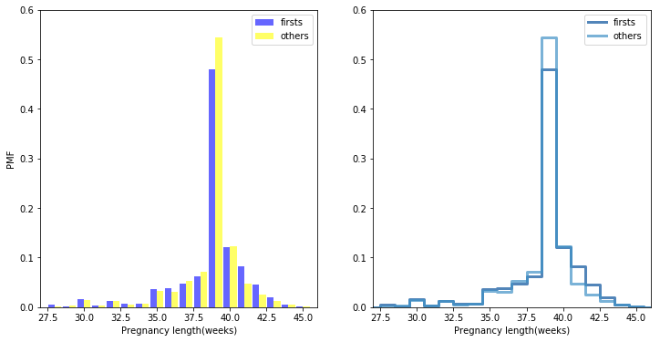

```python
width=0.45
axis = [27, 46, 0, 0.6]
thinkplot.PrePlot(2, cols=2)
thinkplot.Hist(first_pmf, align='right', width=width, color="blue")
thinkplot.Hist(other_pmf, align='left', width=width, color= "yellow")
thinkplot.Config(xlabel='Pregnancy length(weeks)', ylabel='PMF', axis=axis)

thinkplot.PrePlot(2)
thinkplot.SubPlot(2)
thinkplot.Pmfs([first_pmf, other_pmf])
thinkplot.Config(xlabel='Pregnancy length(weeks)', axis=axis)
```

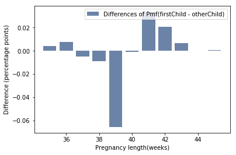

```python
weeks = range(35, 46)
diffs = []
for week in weeks:
    p1 = first_pmf.Prob(week)
    p2 = other_pmf.Prob(week)
    diff = (p1 - p2)
    diffs.append(diff)

thinkplot.Bar(weeks, diffs, label="Differences of Pmf(firstChild - otherChild)")
thinkplot.Config(xlabel='Pregnancy length(weeks)', ylabel='Difference (percentage points)')
```

### Biasing and unbiasing PMFs

Here's the example in the book showing operations we can perform with `Pmf` objects.

Suppose we have the following distribution of class sizes.

```python
d = { 7: 8, 12: 8, 17: 14, 22: 4,
     27: 6, 32: 12, 37: 8, 42: 3, 47: 2 }

pmf = thinkstats2.Pmf(d, label='actual')
pmf
```

```
Pmf({32: 0.18461538461538463, 37: 0.12307692307692308, 7: 0.12307692307692308, 42: 0.046153846153846156, 12: 0.12307692307692308, 47: 0.03076923076923077, 17: 0.2153846153846154, 22: 0.06153846153846154, 27: 0.09230769230769231})
```

This function computes the biased PMF we would get if we surveyed students and asked about the size of the classes they are in.

```python
def BiasPmf(pmf, label):
    new_pmf = pmf.Copy(label=label)

    for x, p in pmf.Items():
        new_pmf.Mult(x, x)

    new_pmf.Normalize()
    return new_pmf
```

The following graph shows the difference between the actual and observed distributions.

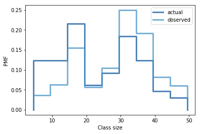

```python
biased_pmf = BiasPmf(pmf, label='observed')
thinkplot.PrePlot(2)
thinkplot.Pmfs([pmf, biased_pmf])
thinkplot.Config(xlabel='Class size', ylabel='PMF')
```

The observed mean is substantially higher than the actual.

```python
print('Actual mean', pmf.Mean())
print('Observed mean', biased_pmf.Mean())
```

```
Actual mean 23.6923076923
Observed mean 29.1233766234
```

If we were only able to collect the biased sample, we could "unbias" it by applying the inverse operation.

```python
def UnbiasPmf(pmf, label=None):
    new_pmf = pmf.Copy(label=label)

    for x, p in pmf.Items():
        new_pmf[x] *= 1/x

    new_pmf.Normalize()
    return new_pmf
```

We can unbias the biased PMF:

```python
unbiased = UnbiasPmf(biased_pmf, label='unbiased')
print('Unbiased mean', unbiased.Mean())
```

```
Unbiased mean 23.6923076923
```

And plot the two distributions to confirm they are the same.

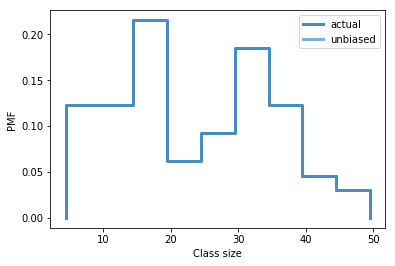

```python
thinkplot.PrePlot(2)
thinkplot.Pmfs([pmf, unbiased])
thinkplot.Config(xlabel='Class size', ylabel='PMF')
```

### Pandas indexing

Here's an example of a small DataFrame.

```python
import numpy as np
import pandas
array = np.random.randn(4, 2)
array
df = pandas.DataFrame(array)
df
```

|  | 0 | 1 |
| --- | --- | --- |
| 0 | 1.521936 | 0.674081 |
| 1 | -0.447508 | -1.938307 |
| 2 | -0.620325 | 0.091324 |
| 3 | 0.993123 | -0.803499 |

We can specify column names when we create the DataFrame:

```python
col = ['A', 'B']
df = pandas.DataFrame(array, columns=col)
df
```

|  | A | B |
| --- | --- | --- |
| 0 | 1.521936 | 0.674081 |
| 1 | -0.447508 | -1.938307 |
| 2 | -0.620325 | 0.091324 |
| 3 | 0.993123 | -0.803499 |

We can also specify an index that contains labels for the rows.

```python
inx = ['a', 'b', 'c', 'd']
df = pandas.DataFrame(array, columns=col, index=inx)
df
```

|  | A | B |
| --- | --- | --- |
| a | 1.521936 | 0.674081 |
| b | -0.447508 | -1.938307 |
| c | -0.620325 | 0.091324 |
| d | 0.993123 | -0.803499 |

Normal indexing selects columns.

```python
df['A']
df.A
```

```
a    1.521936
b   -0.447508
c   -0.620325
d    0.993123
Name: A, dtype: float64
```

We can use the `loc` attribute to select rows.

```python
df.loc['a']
```

```
A    1.521936
B    0.674081
Name: a, dtype: float64
```

If you don't want to use the row labels and prefer to access the rows using integer indices, you can use the `iloc` attribute:

```python
df.iloc[0]
```

```
A    1.521936
B    0.674081
Name: a, dtype: float64
```

`loc` can also take a list of labels.

```python
indices = ['a', 'c']
df.loc[indices]
```

|  | A | B |
| --- | --- | --- |
| a | 1.521936 | 0.674081 |
| c | -0.620325 | 0.091324 |

If you provide a slice of labels, `DataFrame` uses it to select rows.

```python
df['a':'c']
```

|  | A | B |
| --- | --- | --- |
| a | 1.521936 | 0.674081 |
| b | -0.447508 | -1.938307 |
| c | -0.620325 | 0.091324 |

If you provide a slice of integers, `DataFrame` selects rows by integer index.

```python
df[0:2]
```

|  | A | B |
| --- | --- | --- |
| a | 1.521936 | 0.674081 |
| b | -0.447508 | -1.938307 |

```python
t = [1,2,3,4,5,6,7,7,5,4,33]
t[3:4]
```

```
[4]
```

But notice that one method includes the last elements of the slice and one does not.

In general, I recommend giving labels to the rows and names to the columns, and using them consistently.